# Project Business Statistics: E-news Express

**Marks: 60**

## Define Problem Statement and Objectives

## Problem Statement

The advent of e-news, or electronic news, portals has offered us a great opportunity to quickly get updates on the day-to-day events occurring globally. The information on these portals is retrieved electronically from online databases, processed using a variety of software, and then transmitted to the users. There are multiple advantages of transmitting new electronically, like faster access to the content and the ability to utilize different technologies such as audio, graphics, video, and other interactive elements that are either not being used or aren’t common yet in traditional newspapers.

E-news Express, an online news portal, aims to expand its business by acquiring new subscribers. With every visitor to the website taking certain actions based on their interest, the company plans to analyze these actions to understand user interests and determine how to drive better engagement. The executives at E-news Express are of the opinion that there has been a decline in new monthly subscribers compared to the past year because the current webpage is not designed well enough in terms of the outline & recommended content to keep customers engaged long enough to make a decision to subscribe.

[Companies often analyze user responses to two variants of a product to decide which of the two variants is more effective. This experimental technique, known as A/B testing, is used to determine whether a new feature attracts users based on a chosen metric.]

## Objective

The design team of the company has researched and created a new landing page that has a new outline & more relevant content shown compared to the old page. In order to test the effectiveness of the new landing page in gathering new subscribers, the Data Science team conducted an experiment by randomly selecting 100 users and dividing them equally into two groups. The existing landing page was served to the first group (control group) and the new landing page to the second group (treatment group). Data regarding the interaction of users in both groups with the two versions of the landing page was collected. Being a data scientist in E-news Express, you have been asked to explore the data and perform a statistical analysis (at a significance level of 5%) to determine the effectiveness of the new landing page in gathering new subscribers for the news portal by answering the following questions:

1. Do the users spend more time on the new landing page than on the existing landing page?
2. Is the conversion rate (the proportion of users who visit the landing page and get converted) for the new page greater than the conversion rate for the old page?
3. Does the converted status depend on the preferred language?
4. Is the time spent on the new page the same for the different language users?

## Data Dictionary

The data contains information regarding the interaction of users in both groups with the two versions of the landing page.

user_id - Unique user ID of the person visiting the website

group - Whether the user belongs to the first group (control) or the second group (treatment)

landing_page - Whether the landing page is new or old

time_spent_on_the_page - Time (in minutes) spent by the user on the landing page

converted - Whether the user gets converted to a subscriber of the news portal or not

language_preferred - Language chosen by the user to view the landing page

## Import all the necessary libraries

```python
#import the important packages
import pandas as pd #library used for data manipulation and analysis
import numpy as np # library used for working with arrays.
import matplotlib.pyplot as plt # library for plots and visualisations
import seaborn as sns # library for visualisations
%matplotlib inline

import scipy.stats as stats # this library contains a large number of probability distributions as well as a growing library of statistical functions.
```

## Reading the Data into a DataFrame

```python
# Mounting Goodle drive Storage
from google.colab import drive
drive.mount('/content/drive')
```

```python
# read the data
data = pd.read_csv('/content/drive/MyDrive/Data science projects/abtest.csv')
df= data.copy()
pd.options.display.float_format = '{:.2f}'.format
# returns the first 5 rows
data.head(4)
```

|  | user_id | group | landing_page | time_spent_on_the_page | converted | language_preferred |
| --- | --- | --- | --- | --- | --- | --- |
| 0 | 546592 | control | old | 3.48 | no | Spanish |
| 1 | 546468 | treatment | new | 7.13 | yes | English |
| 2 | 546462 | treatment | new | 4.40 | no | Spanish |
| 3 | 546567 | control | old | 3.02 | no | French |

## Explore the dataset and extract insights using Exploratory Data Analysis

- Data Overview
  - Viewing the first and last few rows of the dataset
  - Checking the shape of the dataset
  - Getting the statistical summary for the variables
- Check for missing values
- Check for duplicates

### Data overview

**Displaying first 5 and last 5 rows of data set**

```python
# Display the first five rows
print("First five rows:")
data.head()
```

```
First five rows:
```

|  | user_id | group | landing_page | time_spent_on_the_page | converted | language_preferred |
| --- | --- | --- | --- | --- | --- | --- |
| 0 | 546592 | control | old | 3.48 | no | Spanish |
| 1 | 546468 | treatment | new | 7.13 | yes | English |
| 2 | 546462 | treatment | new | 4.40 | no | Spanish |
| 3 | 546567 | control | old | 3.02 | no | French |
| 4 | 546459 | treatment | new | 4.75 | yes | Spanish |

```python
# Display the last five rows
print("\nLast five rows:")
data.tail()
```

```
Last five rows:
```

|  | user_id | group | landing_page | time_spent_on_the_page | converted | language_preferred |
| --- | --- | --- | --- | --- | --- | --- |
| 95 | 546446 | treatment | new | 5.15 | no | Spanish |
| 96 | 546544 | control | old | 6.52 | yes | English |
| 97 | 546472 | treatment | new | 7.07 | yes | Spanish |
| 98 | 546481 | treatment | new | 6.20 | yes | Spanish |
| 99 | 546483 | treatment | new | 5.86 | yes | English |

**Checking shape of Data set**

```python
print('There are', data.shape[0], 'rows and', df.shape[1], 'columns')
```

```
There are 100 rows and 6 columns
```

**Checking statistical summary of dataset**

```python
# Statiscal summary of data set
data.describe(include='all').T
```

|  | count | unique | top | freq | mean | std | min | 25% | 50% | 75% | max |
| --- | --- | --- | --- | --- | --- | --- | --- | --- | --- | --- | --- |
| user_id | 100.00 | NaN | NaN | NaN | 546517.00 | 52.30 | 546443.00 | 546467.75 | 546492.50 | 546567.25 | 546592.00 |
| group | 100 | 2 | control | 50 | NaN | NaN | NaN | NaN | NaN | NaN | NaN |
| landing_page | 100 | 2 | old | 50 | NaN | NaN | NaN | NaN | NaN | NaN | NaN |
| time_spent_on_the_page | 100.00 | NaN | NaN | NaN | 5.38 | 2.38 | 0.19 | 3.88 | 5.42 | 7.02 | 10.71 |
| converted | 100 | 2 | yes | 54 | NaN | NaN | NaN | NaN | NaN | NaN | NaN |
| language_preferred | 100 | 3 | Spanish | 34 | NaN | NaN | NaN | NaN | NaN | NaN | NaN |

**Checking Data types of data set**

```python
# print a concise summary of the DataFrame
data.info()
```

```
<class 'pandas.core.frame.DataFrame'>
RangeIndex: 100 entries, 0 to 99
Data columns (total 6 columns):
 #   Column                  Non-Null Count  Dtype
---  ------                  --------------  -----
 0   user_id                 100 non-null    int64
 1   group                   100 non-null    object
 2   landing_page            100 non-null    object
 3   time_spent_on_the_page  100 non-null    float64
 4   converted               100 non-null    object
 5   language_preferred      100 non-null    object
dtypes: float64(1), int64(1), object(4)
memory usage: 4.8+ KB
```

**Insights**

- User_id column which contains unique identifiers which are interger data types.
- Group column contains values which has as object data type, this is expected.
- Landing_page column contains values which are all object data type, this is expected.
- Time_spent_on_page column contains values which all float data type, this is in-line with is expected.
- Converted column contains values which are all oblect data type, in-line with whats is expected.
- Language_preferred column contains values which are all object data type, this is in-line with the data type expected.

### Checking missing values across columns

```python
print(data.isnull().sum())
```

```
user_id                   0
group                     0
landing_page              0
time_spent_on_the_page    0
converted                 0
language_preferred        0
dtype: int64
```

There are no missing values in the dataset.

### Checking for duplicates across rows

```python
# Check for duplicates
duplicate_rows = data[data.duplicated()]

# Display duplicate rows, if any
if not duplicate_rows.empty:
    print("Duplicate rows found:")
    print(duplicate_rows)
else:
    print("No duplicate rows found.")
```

```
No duplicate rows found.
```

There are no duplicate rows in the dataset.

### Univariate Analysis

Univariate analysis of Groups

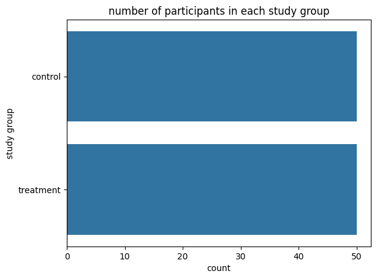

```python
# Plotting a barchart of Group
bar_group = sns.countplot(data=df, y='group')
plt.xlabel('count')
plt.ylabel('study group')
plt.title('number of participants in each study group');
```

- There are two study groups named 'control' and treatment.'
- Each study group has 50 participants each.

Univariate analysis of participants accessing the two Landing pages

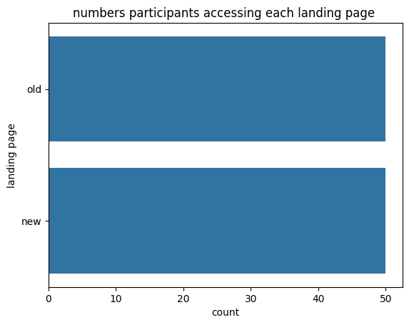

```python
# Plotting a barchart of participants accessing both landing pages.
bar_group = sns.countplot(data=df, y='landing_page')
plt.xlabel('count')
plt.ylabel('landing page')
plt.title('numbers participants accessing each landing page ');
```

- There are two types of landing pages namely 'old' and 'new'.
- Its confirmed that 50 participant opened each landing page as stated in the problem statement.

Univariate analysis of time spent on landing page.

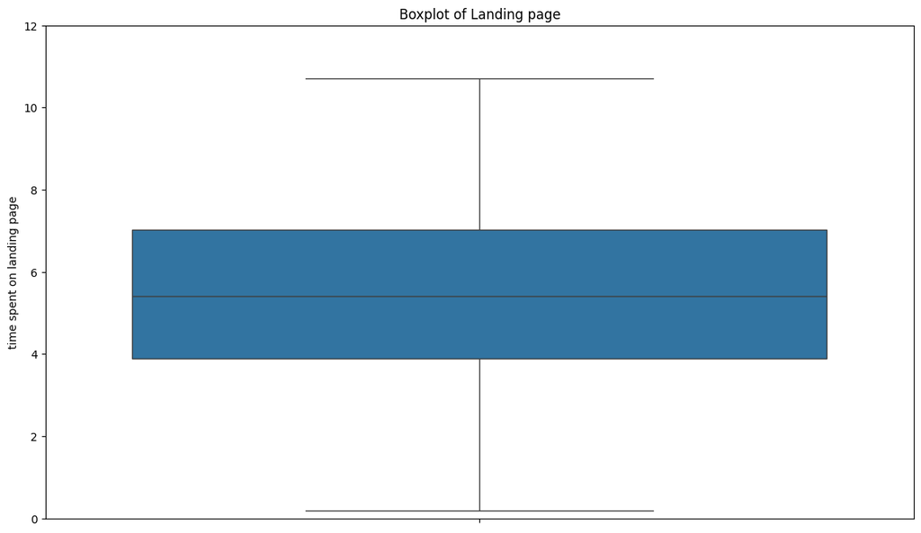

```python
# # Setting plot size
plt.figure(figsize=(14,8))

#Plotting a boxplot of time spent on landing page

sns.boxplot(data= df, y='time_spent_on_the_page')

# Add labels and title
plt.ylabel('time spent on landing page')
plt.title('Boxplot of Landing page');

# Adjust the scale on setting the y-axis limits to [0, 12]
plt.ylim(0, 12)
plt.show()
```

Univariate analysis of converted from Landing page.

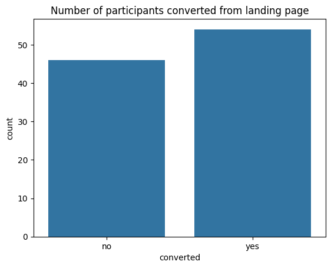

```python
# Plotting a barchart for Converted.
bar_group = sns.countplot(data=df, x='converted')
plt.xlabel('converted')
plt.ylabel('count')
plt.title('Number of participants converted from landing page');
```

- Visually it can be seen that over 50 users converted from any landing page, while around 45-47 users did not convert from any of the landing pages.

Univariate analysis of language preferred by participants.

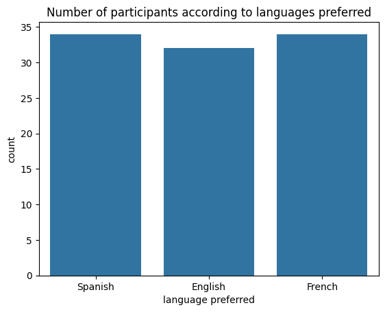

```python
# Plotting a barchart for Converted.
bar_group = sns.countplot(data=df, x='language_preferred')
plt.xlabel('language preferred')
plt.ylabel('count')
plt.title('Number of participants according to languages preferred');
```

- From the chart we can see that at least 30 users preferred any of the languages when accessing the landing page.
- Spanish and French turned out to be the top 2 languages marginally preferred by users.

### Bivariate Analysis

**Bivariate analysis of time spent on each page by each group**

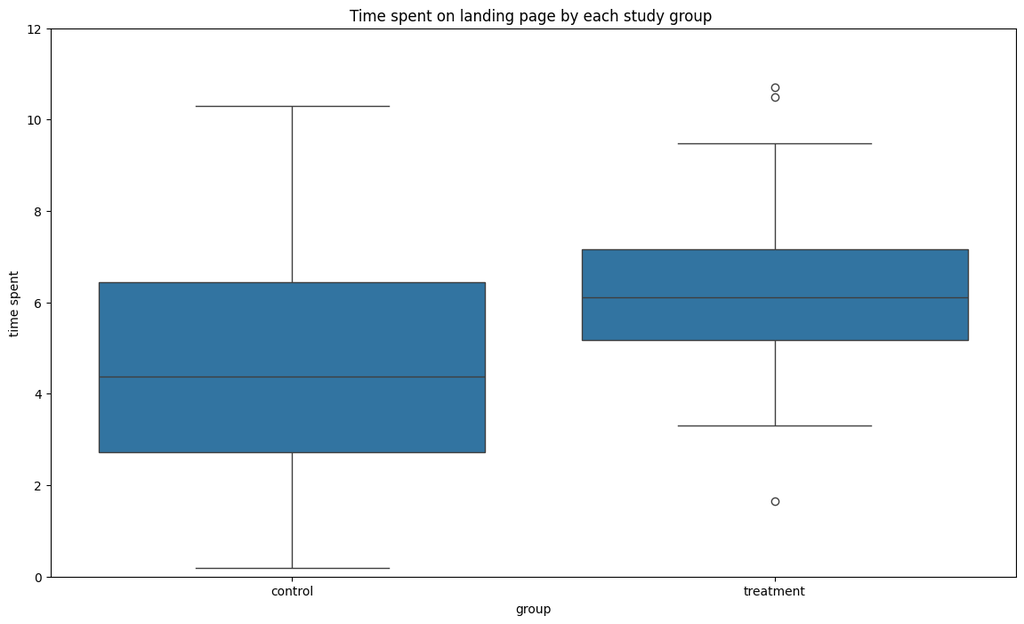

```python
# # Setting plot size
plt.figure(figsize=(14,8))

#Plotting a boxplot of time spent on landing page by each group

sns.boxplot(data= df, x='group', y='time_spent_on_the_page')

# Add labels and title
plt.ylabel('time spent')
plt.xlabel('group')
plt.title('Time spent on landing page by each study group ');

# Adjust the scale on setting the y-axis limits to [0, 12]
plt.ylim(0, 12)
plt.show()
```

**Bivariate analysis of time spent in each land pages**

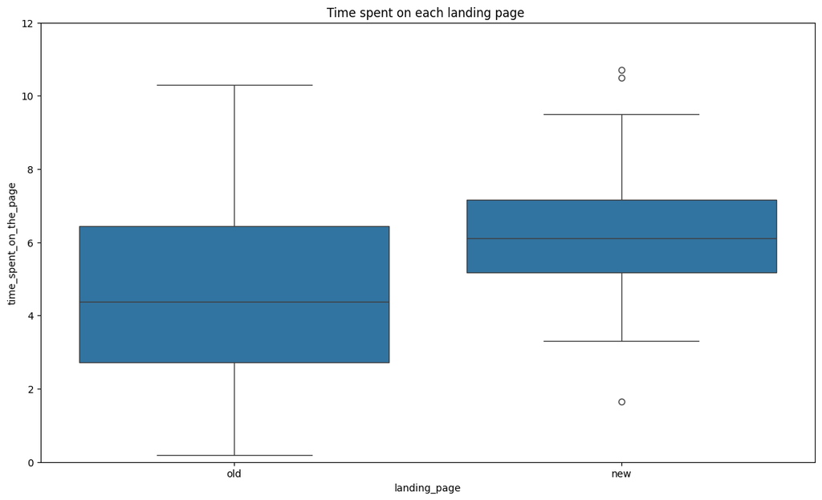

```python
# # Setting plot size
plt.figure(figsize=(14,8))

#Plotting a boxplot of time spent on each landing pages.

sns.boxplot(data= df, x='landing_page', y='time_spent_on_the_page')

# Add labels and title
plt.ylabel('time_spent_on_the_page')
plt.xlabel('landing_page')
plt.title('Time spent on each landing page ');

# Adjust the scale on setting the y-axis limits to [0, 12]
plt.ylim(0, 12)
plt.show()
```

Bivariate analysis of preferred language by each group

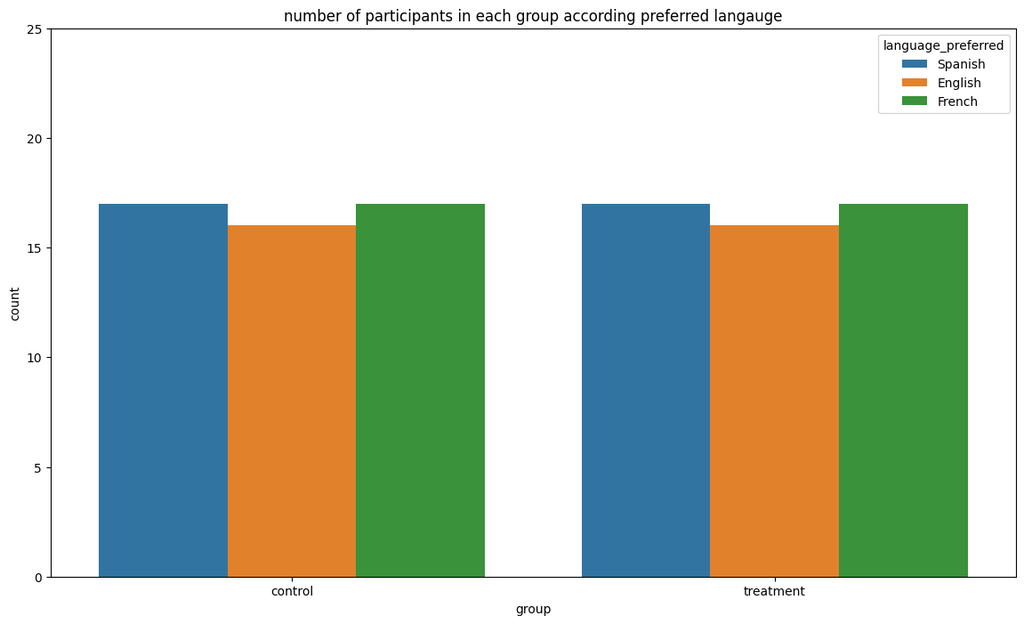

```python
# Plotting a barchart of Group
plt.figure(figsize=(14,8))
bar_group = sns.countplot(data=df, x='group', hue='language_preferred')
plt.ylabel('count')
plt.xlabel('group')
plt.title('number of participants in each group according preferred langauge')

#Adjust the scale on setting the y-axis limits to [0, 25]
plt.ylim(0, 25)
plt.show()
```

**Insight**

- At least 15 users preferred any of the languages in both study groups.
- Preference around any of the languages in the study group was margininally around 15-17 users, though Spanish and French were the most preferred languages in both study groups.

Bivariate analysis of time spent on landing page by preferred language

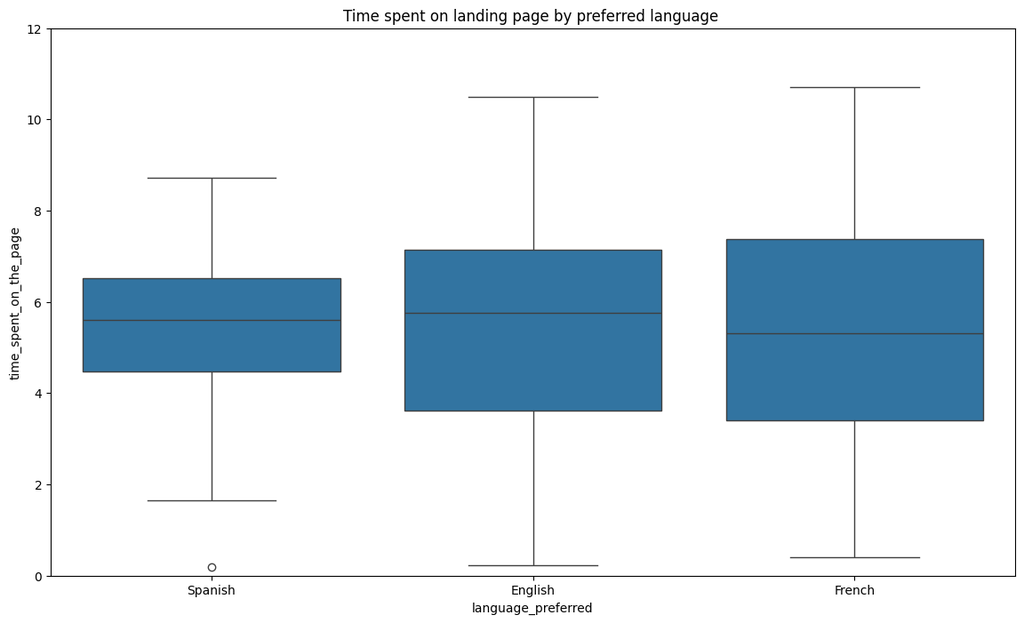

```python
# # Setting plot size
plt.figure(figsize=(14,8))

#Plotting a boxplot of time spent by preferred language.

sns.boxplot(data= df, x='language_preferred', y='time_spent_on_the_page')

# Add labels and title
plt.ylabel('time_spent_on_the_page')
plt.xlabel('language_preferred')
plt.title('Time spent on landing page by preferred language ');

# Adjust the scale on setting the y-axis limits to [0, 12]
plt.ylim(0, 12)
plt.show()
```

**Insight**

- Users spent marginally similiar time using any of the 3 languages, around 5-6 minutes on the median.
- The range of time spent by users who preferred English or French was significantly wide, around 0-11 minutes for both sets of users.

Bivariate analysis of time spent by each study group according to preferred language.

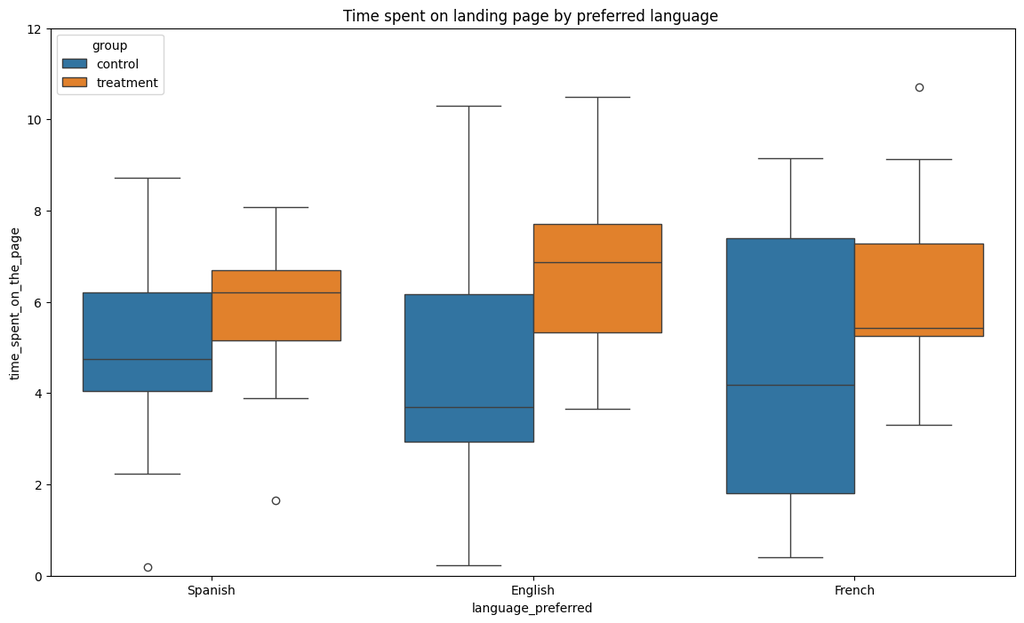

```python
# # Setting plot size
plt.figure(figsize=(14,8))

#Plotting a boxplot of time spent by each group according to preferred language.

sns.boxplot(data= df, x='language_preferred', y='time_spent_on_the_page', hue='group',dodge='True')

# Add labels and title
plt.ylabel('time_spent_on_the_page')
plt.xlabel('language_preferred')
plt.title('Time spent on landing page by preferred language ');

# Adjust the scale on setting the y-axis limits to [0, 12]
plt.ylim(0, 12)
plt.show()
```

**Insight**

Bivariate analysis of Coversion according to group

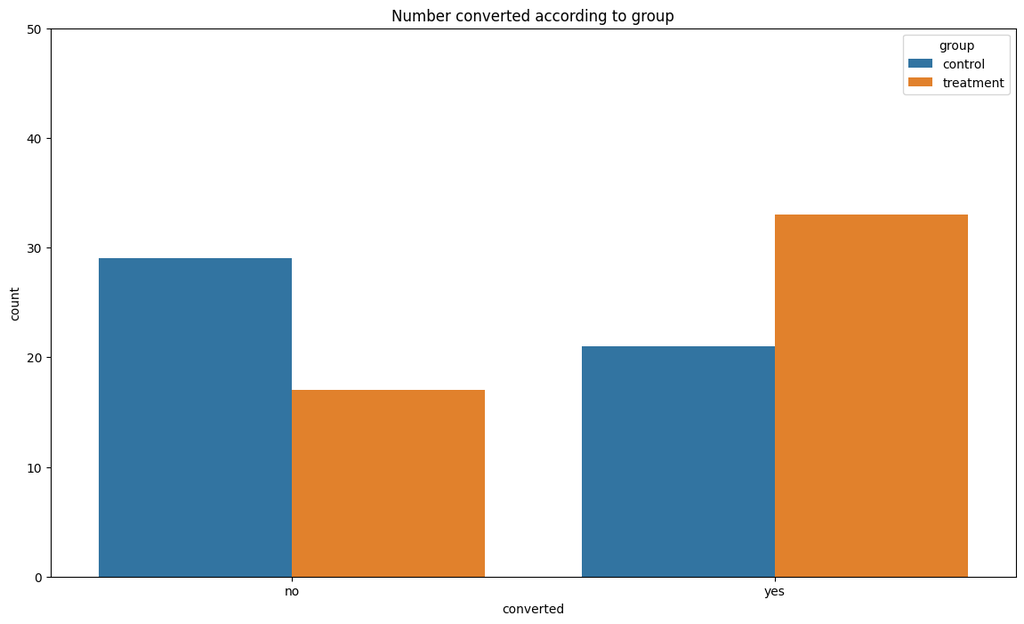

```python
# # Setting plot size
plt.figure(figsize=(14,8))

#Plotting a stacked barplot of number converted according to study group.

sns.countplot(data= df, x='converted', hue='group')

# Add labels and title
plt.xlabel('converted')
plt.title('Number converted according to group');

# Adjust the scale on setting the y-axis limits to [0, 12]
plt.ylim(0, 50)
plt.show()
```

Bivariate analysis of the relationship between those converted and the time spent on landing page

**Insight**

- Over 30 users converted from the treatment group when compared to the control group where about 20 users converted.
- About 28 to 29 users from the control group failed to convert when compared to the about 15-17 users who did not convert in the treatment group.
- The above findings might suggest there are perculiar factors in the new landing page that is capturing the interest of more users when compared to the old landing page.

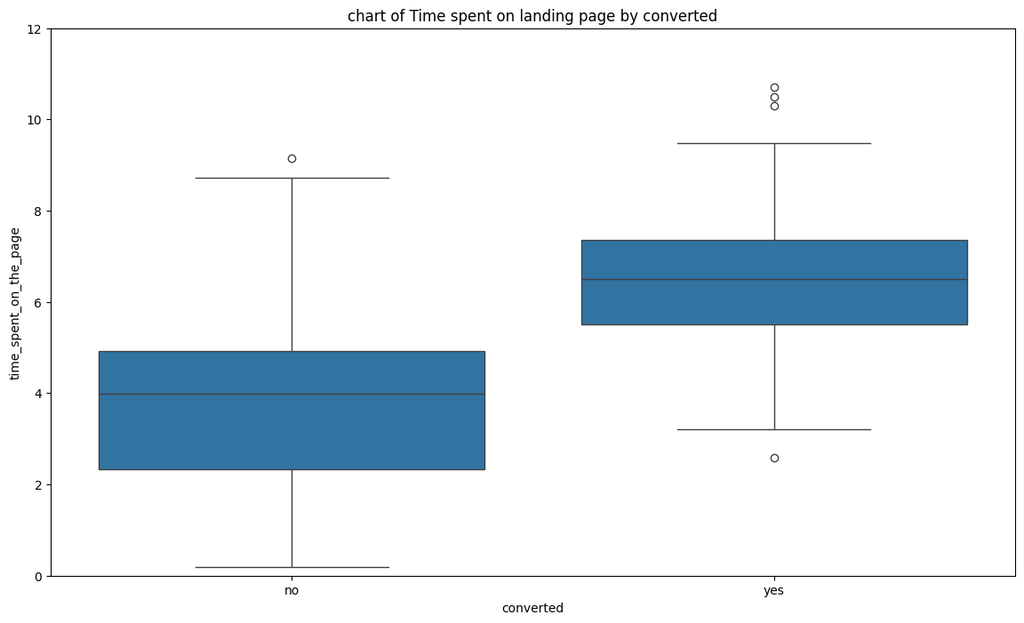

```python
# # Setting plot size
plt.figure(figsize=(14,8))

#Plotting a boxplot of relationship between converted and time spent on landing page.

sns.boxplot(data= df, x='converted', y='time_spent_on_the_page')

# Add labels and title
plt.ylabel('time_spent_on_the_page')
plt.xlabel('converted')
plt.title('chart of Time spent on landing page by converted');

# Adjust the scale on setting the y-axis limits to [0, 20]
plt.ylim(0, 12)
plt.show()
```

**Insights**

- Users who got converted spent more median time on the landing page than those who don't. This implies that there may be a relationship between those converted and time spent on a landing page.
- This may be explained as landing pages with more captivating contents may appeal to a large proportion of users thus pushing them to explore the site more deeply.

## 1. Do the users spend more time on the new landing page than the existing landing page?

### Perform Visual Analysis

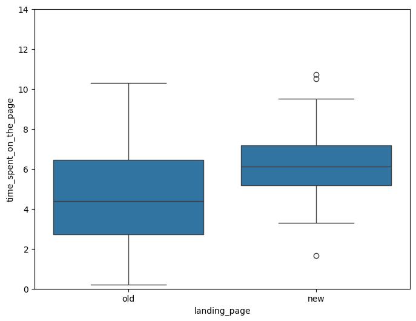

```python
# visual analysis of the time spent on the new page and the time spent on the old page
plt.figure(figsize=(8,6))
sns.boxplot(x = 'landing_page', y = 'time_spent_on_the_page', data = df)
# Adjust the scale on setting the y-axis limits to [0, 12]
plt.ylim(0, 14)
plt.show()
```

**Insight**

- The time spent on both old and new landing page is just about normally distributed, with few outliers in the new landing page.
- Median time spent on the new landing page was more than the median time spent on the old landing page.
- The range of time spent on the old landing page was significantly wider when compared to the range of time spent on the new landing page.
- This may point to a signifcant improvement in time spent on the new landing page when compared to the old landing page. This observation will be further tested in this section.

### Step 1: Define the null and alternate hypotheses

The null and alternative hypotheses is formulated as:

H0 : The time spent by users in new landing page is less or equal to the time spent on the existing landing page

Ha : The time spent by users in new landing page is more than the time spent on the existing landing page

### Step 2: Select Appropriate test

This problem is concerning two independent populations,the group who use the existing landing and the group that use the new landing page. The variable here is time spent on the landing pages when they visit. The population standard deviation is also not known. Hence, **One-tailed two sample independent T-test** is the appropriate test for this problem.

Let's test whether the T-test assumptions are satisfied or not Continuous data - Yes, the usage time is measured on a continuous scale.

1. Normally distributed populations - Yes, we can assume these based on the boxplot we viewed earlier.
2. Independent populations - As we are taking random samples for two different type of users, the two samples are from two independent populations.
3. Random sampling from the population - Yes, we are informed that the collected sample is a simple random sample.

### Step 3: Decide the significance level

The significant level used will be $\alpha = 0.05$

### Step 4: Collect and prepare data

```python
# create separate variables to store the time spent on the page with respect to the two landing pages
Existing_landing_page = df[df['landing_page']=='old']['time_spent_on_the_page']
New_landing_page = df[df['landing_page']=='new']['time_spent_on_the_page']
```

```python
# Calculating the mean and standard deviations of time spent on each landing page
print('Standard deviation of time spent on existing landing page is',round(np.std(Existing_landing_page),2))
print('Standard deviation of time spent on new landing page is', round(np.std(New_landing_page),2))
print('mean time spent on existing landing page is', round(np.mean(Existing_landing_page),2))
print('mean time spent on new landing page is', round(np.mean(New_landing_page),2))
```

```
Standard deviation of time spent on existing landing page is 2.56
Standard deviation of time spent on new landing page is 1.8
mean time spent on existing landing page is 4.53
mean time spent on new landing page is 6.22
```

### Step 5: Calculate the p-value

The ttest_ind() function of Scipy will be used to compute the test statistic and p-value. Since variance is not the same in both population, the parameter equal_var will equal false.

```python
#import the required functions
from scipy.stats import ttest_ind

# find the p-value
test_stat, p_value = ttest_ind(New_landing_page.dropna(),Existing_landing_page.dropna(), equal_var = False, alternative = 'greater')
print('The p-value is ', p_value)
```

```
The p-value is  0.0001392381225166549
```

### Step 6: Compare the p-value with $\alpha$

```python
# print the conclusion based on p-value
if p_value < 0.05:
    print(f'As the p-value {p_value} is less than the level of significance, we reject the null hypothesis.')
else:
    print(f'As the p-value {p_value} is greater than the level of significance, we fail to reject the null hypothesis.')
```

```
As the p-value 0.0001392381225166549 is less than the level of significance, we reject the null hypothesis.
```

### Step 7: Draw inference

With the P-value less than the level of significance, there is enough evidence to reject the null hypothesis and this implies that time spent on the new landing page by users is more than those spent on the old landing page.

## 2. Is the conversion rate (the proportion of users who visit the landing page and get converted) for the new page greater than the conversion rate for the old page?

### Perform visual analysis

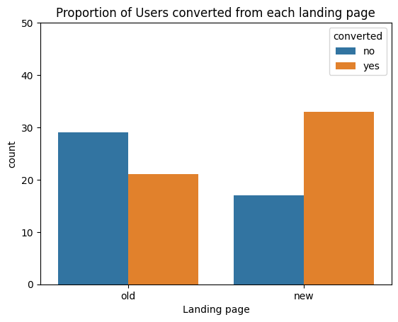

```python
# Plotting a barchart for Conversion proportion in each landing page
bar_group = sns.countplot(data=df, x='landing_page', hue ='converted')
plt.xlabel('Landing page')
plt.ylabel('count')
plt.title('Proportion of Users converted from each landing page')

# Adjust the scale on setting the y-axis limits to [0, 12]
plt.ylim(0, 50);
```

From the above visuals, we can see that the new landing page has more proportion of users converted when compared to the older landing page which had more proportion of users not converted. This will be further tested through hypothesis testing.

### Define the null and alternate hypothesis

The null and alternative hypotheses is formulated as:

H0 : The conversion rate of the new llanding page is less than or equal to the conversion rate of the old landing page

Ha : The conversion rate of the new landing page is greater than that of the old landing page

### Select appropriate test

Let's test whether the Z-test assumptions are satisfied or not

- Binomally distributed population - Yes, user is converted or not in each landing page population
- Random sampling from the population - Yes, we are informed that the collected sample is a simple random sample.
- Can the binomial distribution be approximated to normal distribution - Yes. For binary data, CLT works slower than usual. The standard thing is to check whether np and n(1-p) are greater than or equal to 10. Here, n and p refer to the sample size and sample proportion respectively.

np_1 > 10

n(1-p_1) > 10

np_2 > 10

n(1-p_2) > 10

These were all checked below, and found meeting the conditions for 2 sample z-test to be used.

```python
#getting the proportion of conversions in  landing page
n_old= len(df[(df['landing_page'] == 'old') & (df['converted'] == 'yes')])
p_old= len(df[df['landing_page']=='old'])
n_prop_old= n_old/p_old

#Checking if the conversion rate and sample size of the existing page is greater than 10
np_old1= p_old*(n_prop_old) # check sample size
np_old2= p_old*(p_old-n_old/p_old) #checking proportion size

#getting the proportion of conversions in the new  anding page
n_new= len(df[(df['landing_page'] == 'new') & (df['converted'] == 'yes')])
p_new= len(df[df['landing_page']=='new'])
n_prop_new= n_new/p_new
np_new1= p_new*(n_prop_new)

#Checking if the conversion rate and sample size of the new page is greater than 10
np_new1= p_new*(n_prop_new) #checking sample size
np_new2= p_old*p_new-n_new/p_new #checking proportion size

print('The np and n(1-p) for both proportions are',np_old1,'&',np_new1,'respectively and',np_old2,'&',np_new2,'respectively','which are all greater than 10 thus meeting the criteria that both binomial distributions can be approximated to normal distributions')
```

[output not shown]

It is clear that both sample size(n) and sample proportion(p) for conversion rate in both existing and new landing page are above 10. Hence, the two sample z-test can be applied.

### Decide significance level

The significant level used will be $\alpha = 0.05$

### Collect and prepare data

```python
# Count of conversions in both landing pages
n_old= len(df[(df['landing_page'] == 'old') & (df['converted'] == 'yes')])  #conversions in existing landing page
n_new= len(df[(df['landing_page'] == 'new') & (df['converted'] == 'yes')])  #conversions in new landing page

#Sample sizes of both landing pages
p_old= len(df[df['landing_page']=='old'])  #existing page sample size
p_new= len(df[df['landing_page']=='new'])  #new page sample size
```

### Calculate P-value

```python
# import the required fuction
from statsmodels.stats.proportion import proportions_ztest

# set the count of conversions in both landing pages
conversion_count = np.array([n_old, n_new])

# set the sample sizes of both landing pages
nobs = np.array([p_old, p_new])

# find the p-value
test_stat, p_value = proportions_ztest(conversion_count, nobs)
print('The p-value is ' + str(p_value))
```

```
The p-value is 0.016052616408112556
```

### Compare the p-value with $\alpha$

```python
# print the conclusion based on p-value as compared with earlier stated level of significance.
if p_value < 0.05:
    print(f'As the p-value {p_value} is less than the level of significance, we reject the null hypothesis.')
else:
    print(f'As the p-value {p_value} is greater than the level of significance, we fail to reject the null hypothesis.')
```

```
As the p-value 0.016052616408112556 is less than the level of significance, we reject the null hypothesis.
```

### Draw Inference

With the null hypothesis rejected, I can say that there is enough evidence to support the alternate theory that the conversion rate on the new landing page is greater than the conversion rate on the older landing page

## 3. Is the conversion and preferred language are independent or related?

### Perform Visual analysis

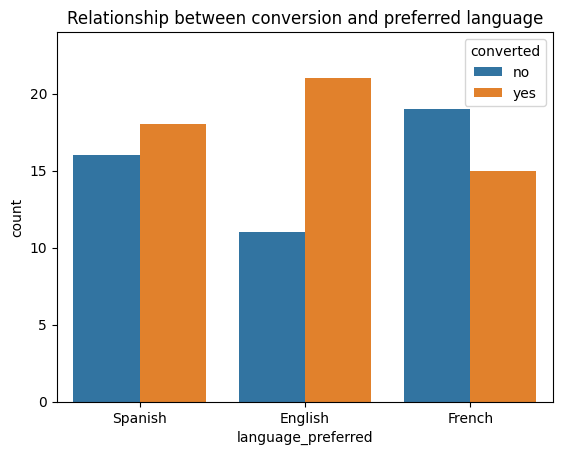

```python
# Plotting a barchart for Conversion count ilann relation to preferred language.
bar_group = sns.countplot(data=df, x='language_preferred', hue ='converted')
plt.xlabel('language_preferred')
plt.ylabel('count')
plt.title('Relationship between conversion and preferred language')

# Adjust the scale on setting the y-axis limits to [0, 12]
plt.ylim(0, 24);
```

Frm the chart we can see that user who preferred English language where twice more likely in getting converted. The proportion of users who were converted were marginal in the other two language preference. Infact, French preferred users had more none-conversions than conversions, this might be a pointer to poor readerbilty and user experience or even translation issues with the French versions of the landing pages.However, this relationships observed needs to be further tested via hypothesis testing.

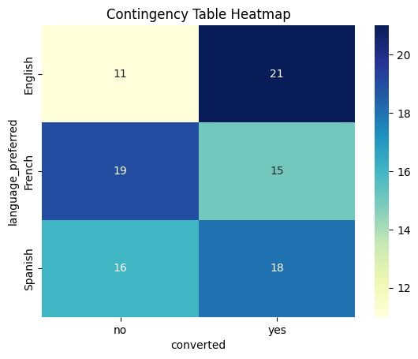

```python
# ceate a contingency table
contingency_table= pd.crosstab(df['language_preferred'], df['converted'])

# Visualize the contingency table using a heatmap
sns.heatmap(contingency_table, annot=True, fmt='d', cmap='YlGnBu', cbar=True)
plt.title('Contingency Table Heatmap')
plt.show()
```

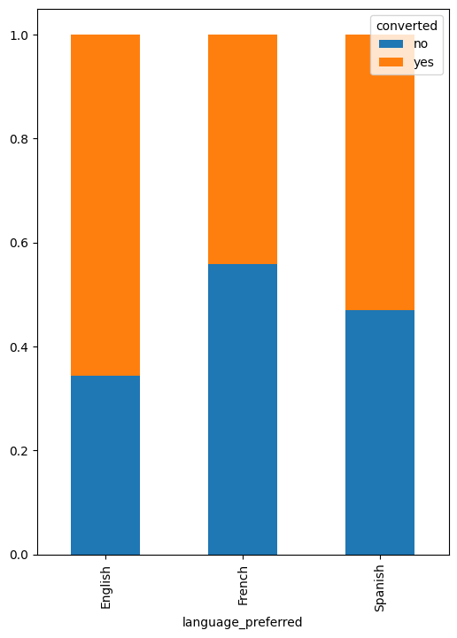

```python
pd.crosstab(df['language_preferred'],df['converted'],normalize='index').plot(kind="bar", figsize=(6,8), stacked=True);
```

The stacked bar chart above shows the proportion of conversions with respect to user preferred language,which further butresses the points I earlier mentioned.Still, further testing needed.

### Define Null and alternate hypothesis

The null and alternative hypotheses is formulated as:

H0 : Conversion is independent of the user preferred language

Ha : Conversion is related to the user preferred language.

### Select appropriate test

The Chi Square test of independence is the appropriate test for this problem, as the below criteria has been met to use the test.

1. Categorical variables - Yes,becuase Conversion and user_preferred language columns contain only categorical variables.
2. Expected value of the number of sample observations in each level of the variable is at least 5 - Yes, the number of observations in each level is greater than 5.This will be further highlighted when the contigency table is visualized in the next section. 3.Random sampling from the population - Yes, we are informed that the collected sample is a simple random sample.

### Decide level of significance

The significant level used will be $\alpha = 0.05$

### Collect data and prepare data

```python
contingency_table
```

| converted language_preferred | no | yes |
| --- | --- | --- |
| English | 11 | 21 |
| French | 19 | 15 |
| Spanish | 16 | 18 |

### Calculate p-value

The function The `chi2_contingency() will be used to compute the test.

```python
# import the required function
from scipy.stats import chi2_contingency

# find the p-value
chi, p_value, dof, expected = chi2_contingency(contingency_table)
print('The p-value is', p_value)
```

```
The p-value is 0.2129888748754345
```

### Compare P-value with level of significance

```python
# print the conclusion based on p-value as compared with earlier stated level of significance.
if p_value < 0.05:
    print(f'As the p-value {p_value} is less than the level of significance, we reject the null hypothesis.')
else:
    print(f'As the p-value {p_value} is greater than the level of significance, we fail to reject the null hypothesis.')
```

```
As the p-value 0.2129888748754345 is greater than the level of significance, we fail to reject the null hypothesis.
```

### Draw inference

Since the null hypothesis has failed to be rejected. I can say that there is not enough evidence to support the claim that there is a relationship between conversion and User language preferences eventhough exploratory analysis seem to back a relationship been present.